# Predição de votação Deputados

João Lucas

14 de dezembro de 2017

```r
library(readr)
library(leaps)
library(ggplot2)
library(plotly)
library(knitr)
library(caret)
library(elasticnet)
library(lars)
```

```r
df <- read.csv("C:/Users/João Lucas/Desktop/eleicoes2014.csv",fileEncoding = "latin1")
colnames(df)[13] <- "recursos_pessoas_fisicas"
```

### Para tratar os dados, vamos olhar primeiro as colunas que contém na ao longo dos seus dados. Esses dados são erros na hora de se montar o csv e, por isso, não é de bom uso para nós. Podemos arrumar isso substituindo esses valores NA, setando esses números para a média de cada coluna em que esses valores se encontram.

```r
media_partidos <- mean(df$recursos_de_partidos, na.rm = TRUE)
df$recursos_de_partidos[is.na(df$recursos_de_partidos)] <- media_partidos

media_comites <- mean(df$recursos_de_outros_candidatos.comites, na.rm = TRUE)
df$recursos_de_outros_candidatos.comites[is.na(df$recursos_de_outros_candidatos.comites)] <- media_comites

media_proprios <- mean(df$recursos_proprios, na.rm = TRUE)
df$recursos_proprios[is.na(df$recursos_proprios)] <- media_proprios

media_fisicas <- mean(df$recursos_pessoas_fisicas, na.rm = TRUE)
df$recursos_pessoas_fisicas[is.na(df$recursos_pessoas_fisicas)] <- media_fisicas

media_juridicas <- mean(df$recursos_de_pessoas_juridicas, na.rm = TRUE)
df$recursos_de_pessoas_juridicas[is.na(df$recursos_de_pessoas_juridicas)] <- media_juridicas
```

# Usando todas as variáveis disponíveis, tune (usando validação cruzada): (i) um modelo de regressão Ridge, (ii) um modelo de regressão Lasso e (iii) um modelo KNN. Para os modelos de regressão linear, o parâmetro a ser tunado é o lambda.

Para ‘tunar’ nossas variáveis vamos usar validação cruzada. ‘Tuná-las’ significa que vamos ter que fazer uma buscar para encontrar os melhores valores para que o teste seja melhor. Como visto no tutorial, existem várias maneiras de se fazer validação cruzada:holdout, k-fold e leave-one-out. Para essa questão, ultilizaremos a k-fold nas 3 tunagens.

Nesse processo de tunagem, vamos tirar as variaveis cargo,pelo fato de que essa variável tem poucos fatores, e a variável nome, para não nos atrapalhar no processo, tomando um longo tempo para isso.

RIDGE

Ridge regression é um método de regularização que tem como principal objetivo suavizar os atributos que aumentem o ruído no modelo, evitando o overffiting.

Como vamos procurar pelos lambdas, temos que ter a consiência de que: Lambda grande:Bias grande e baixa variância Lambda pequeno: Bias pequeno e alta variância,

*Tiraremos a variavel nome nos nossos modelos para não ser tão demorado o processo de “geramento” dos dados*

```r
fitControl <- trainControl(method = "repeatedcv", repeats = 5, number = 5)
lambda.grid <- expand.grid(lambda = seq(0, 2, by=0.1))

ridge <- train(votos ~ ., data = df %>% select(-cargo) %>% select(-nome),
               method='ridge',
               tuneGrid = lambda.grid,
               trControl = fitControl,
               metric='RMSE',
               preProcess=c('scale', 'center','nzv')) # nzv para resolver o 0 variance


ridge
```

```
## Ridge Regression
##
## 4152 samples
##   23 predictor
##
## Pre-processing: scaled (34), centered (34), remove (192)
## Resampling: Cross-Validated (5 fold, repeated 5 times)
## Summary of sample sizes: 3321, 3323, 3322, 3322, 3320, 3323, ...
## Resampling results across tuning parameters:
##
##   lambda  RMSE      Rsquared   MAE
##   0.0     32819.51  0.4836377  12855.36
##   0.1     32985.29  0.4832217  12549.17
##   0.2     33401.12  0.4843465  12802.13
##   0.3     33950.26  0.4855829  13186.03
##   0.4     34620.39  0.4866549  13672.37
##   0.5     35394.60  0.4875286  14225.46
##   0.6     36255.65  0.4882266  14831.23
##   0.7     37187.68  0.4887803  15479.77
##   0.8     38176.72  0.4892180  16163.03
##   0.9     39210.75  0.4895632  16868.02
##   1.0     40279.55  0.4898347  17589.53
##   1.1     41374.52  0.4900470  18320.43
##   1.2     42488.43  0.4902118  19054.40
##   1.3     43615.25  0.4903383  19788.92
##   1.4     44749.94  0.4904336  20521.65
##   1.5     45888.32  0.4905037  21254.09
##   1.6     47026.92  0.4905531  21984.19
##   1.7     48162.85  0.4905855  22709.98
##   1.8     49293.73  0.4906041  23428.62
##   1.9     50417.60  0.4906113  24141.37
##   2.0     51532.84  0.4906090  24845.09
##
## RMSE was used to select the optimal model using the smallest value.
## The final value used for the model was lambda = 0.
```

Com o resultado final do lambda = 0 vemos um lambda muito pequeno, ou seja, Bias baixo e variância alta.

```r
ridge_prediction <- predict(ridge,df %>% select(-cargo) %>% select(-nome) %>% select(-votos))

ridge_data <- data.frame(pred = ridge_prediction, obs = df$votos)

ridge_cv <- round(defaultSummary(ridge_data),digits = 4)

ridge_cv
```

```
##       RMSE   Rsquared        MAE
## 32368.5680     0.4889 12468.4444
```

Em termos de predição no teste, o modelo Ridge tem um R² de 0.4889, nos mostrando que tem um valor maior nos dados de teste do que no de treino.

LASSO

O lasso, que é mais um método de análise de regressão, executa a seleção e regularização de variáveis para aumentar a precisão da predição, podendo selecionar as variáveis para 0 se necessário.

```r
lasso <- train(votos ~ ., data = df %>% select(-setor_economico_receita) %>% select(-cargo) %>% select(-nome) %>% select(-setor_economico_despesa),
               method='lasso',
               trControl = fitControl,
               metric='RMSE',
               tuneLength = 50,
               preProcess=c('scale', 'center'))


lasso
```

```
## The lasso
##
## 4152 samples
##   21 predictor
##
## Pre-processing: scaled (84), centered (84)
## Resampling: Cross-Validated (5 fold, repeated 5 times)
## Summary of sample sizes: 3322, 3321, 3322, 3322, 3321, 3320, ...
## Resampling results across tuning parameters:
##
##   fraction   RMSE      Rsquared   MAE
##   0.1000000  32756.07  0.4748923  12846.96
##   0.1163265  32744.49  0.4758080  12847.52
##   0.1326531  32742.65  0.4765494  12876.76
##   0.1489796  32744.46  0.4771001  12918.83
##   0.1653061  32737.22  0.4778544  12960.83
##   0.1816327  32736.01  0.4783634  13006.83
##   0.1979592  32741.18  0.4787066  13066.45
##   0.2142857  32750.47  0.4789089  13134.40
##   0.2306122  32760.16  0.4790275  13196.67
##   0.2469388  32762.06  0.4792360  13244.48
##   0.2632653  32764.90  0.4793425  13279.57
##   0.2795918  32770.60  0.4793424  13312.68
##   0.2959184  32774.91  0.4793529  13337.11
##   0.3122449  32782.25  0.4792766  13360.70
##   0.3285714  32791.23  0.4791292  13383.90
##   0.3448980  32802.52  0.4789037  13405.42
##   0.3612245  32814.05  0.4786426  13423.54
##   0.3775510  32826.01  0.4783649  13439.10
##   0.3938776  32837.17  0.4780968  13452.01
##   0.4102041  32847.46  0.4778368  13462.60
##   0.4265306  32855.47  0.4776292  13470.96
##   0.4428571  32860.82  0.4774770  13477.44
##   0.4591837  32864.76  0.4773577  13482.19
##   0.4755102  32868.45  0.4772418  13486.49
##   0.4918367  32870.67  0.4771669  13489.11
##   0.5081633  32871.19  0.4771457  13490.23
##   0.5244898  32871.71  0.4771229  13491.71
##   0.5408163  32871.98  0.4771104  13492.76
##   0.5571429  32871.90  0.4771102  13493.57
```

[output cut: 9 more lines]

```
##   0.7204082  32872.80  0.4770781  13499.56
##   0.7367347  32872.95  0.4770740  13500.12
##   0.7530612  32873.11  0.4770696  13500.68
##   0.7693878  32873.27  0.4770655  13501.22
##   0.7857143  32873.45  0.4770603  13501.84
##   0.8020408  32873.62  0.4770556  13502.46
##   0.8183673  32873.81  0.4770507  13503.12
##   0.8346939  32874.00  0.4770454  13503.81
##   0.8510204  32874.20  0.4770399  13504.52
##   0.8673469  32874.41  0.4770342  13505.26
##   0.8836735  32874.64  0.4770282  13506.01
##   0.9000000  32874.88  0.4770217  13506.78
##
## RMSE was used to select the optimal model using the smallest value.
## The final value used for the model was fraction = 0.1816327.
```

```r
lasso_prediction <- predict(lasso,df %>% select(-setor_economico_receita) %>% select(-cargo) %>% select(-nome) %>% select(-setor_economico_despesa))

lasso_data <- data.frame(pred = lasso_prediction, obs = df$votos)

lasso_cv<- round(defaultSummary(lasso_data),digits = 4)

lasso_cv
```

```
##       RMSE   Rsquared        MAE
## 32000.5412     0.5005 12901.1708
```

KNN

Para esse modelo de regressão, o nome já dá uma dica boa sobre como o algoritmo funciona. As tunagens do “vizinho proximo” se dará exatamente como o nome fala. O knn vai buscar os elementos que estão mais próximos para dar um match em seus resultados, ou seja, se uma icógnita x está mais perto de y do que de z, ela terá o valor y.

Abaixo, vamos tunar o modelo 15 vezes, tirando do estudo as variáveis CARGO, NOME, SETOR_ECONOMICO_RECEITA E SETOR_ECONOMICO_DESPESA:

```r
trctrl <- trainControl(method = "repeatedcv", number = 10, repeats = 3)


knn <- train(votos ~ ., data = df %>% select(-cargo) %>% select(-nome) %>% select(-setor_economico_receita) %>% select(-setor_economico_despesa),
             method = "knn",
             trControl=trctrl,
             metric='RMSE',
             na.action = na.exclude,
             preProcess = c("center", "scale","nzv"),
             tuneLength = 15)

knn
```

```
## k-Nearest Neighbors
##
## 4152 samples
##   21 predictor
##
## Pre-processing: centered (32), scaled (32), remove (52)
## Resampling: Cross-Validated (10 fold, repeated 3 times)
## Summary of sample sizes: 3738, 3737, 3737, 3736, 3737, 3736, ...
## Resampling results across tuning parameters:
##
##   k   RMSE      Rsquared   MAE
##    5  33580.80  0.4506564  11428.66
##    7  32566.33  0.4743418  11259.37
##    9  31926.50  0.4916648  11102.36
##   11  31670.08  0.5007793  11038.72
##   13  31418.22  0.5096503  10988.39
##   15  31397.71  0.5099177  11026.82
##   17  31329.73  0.5127952  11049.49
##   19  31304.26  0.5140684  11073.56
##   21  31322.71  0.5141344  11103.64
##   23  31315.12  0.5155069  11128.90
##   25  31323.19  0.5159195  11148.81
##   27  31329.33  0.5165789  11178.41
##   29  31338.70  0.5173538  11197.59
##   31  31362.15  0.5176226  11211.74
##   33  31401.16  0.5175375  11205.69
##
## RMSE was used to select the optimal model using the smallest value.
## The final value used for the model was k = 19.
```

```r
knn_prediction <- predict(knn,df %>% select(-setor_economico_receita) %>% select(-cargo) %>% select(-nome) %>% select(-setor_economico_despesa))

knn_data <- data.frame(pred = knn_prediction, obs = df$votos)

knn_show_cv <- round(defaultSummary(knn_data),digits = 4)

knn_show_cv
```

```
##       RMSE   Rsquared        MAE
## 32869.1252     0.4878 10507.0009
```

# 2.Compare os três modelos em termos do erro RMSE de validação cruzada

Podemos plotar os gráficos dos três modelos em função de seus RMSE e compará-los:

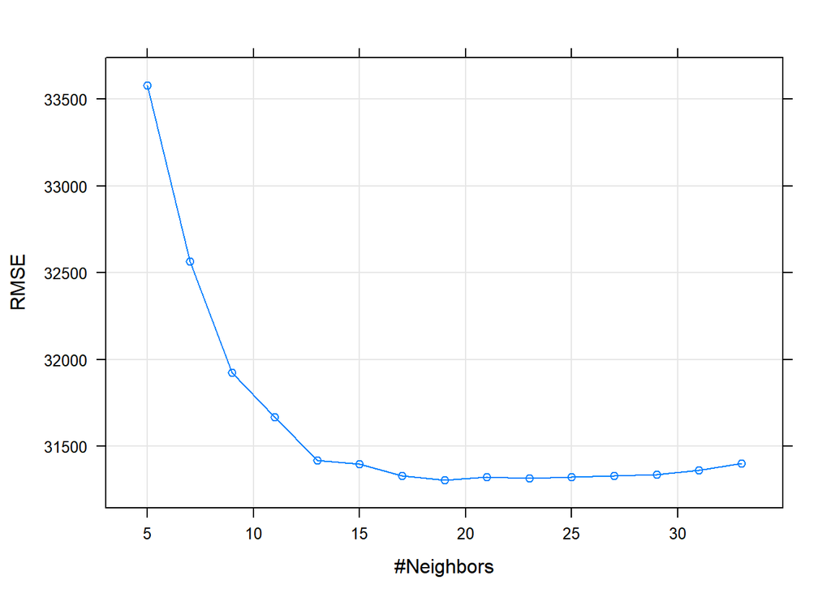

```r
plot(knn,ylab ="RMSE")
```

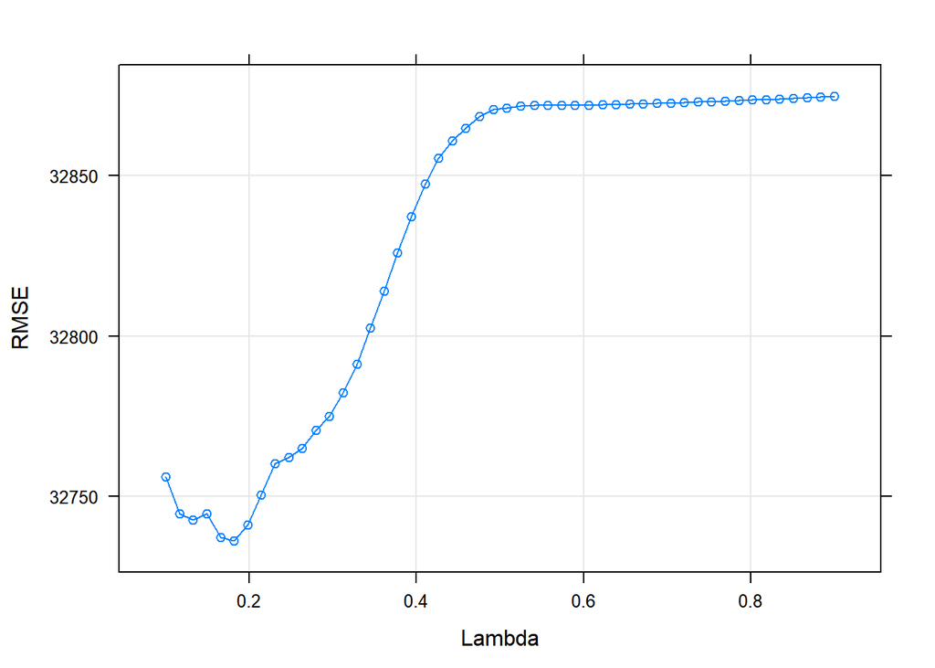

```r
plot(lasso,xlab="Lambda",ylab = "RMSE")
```

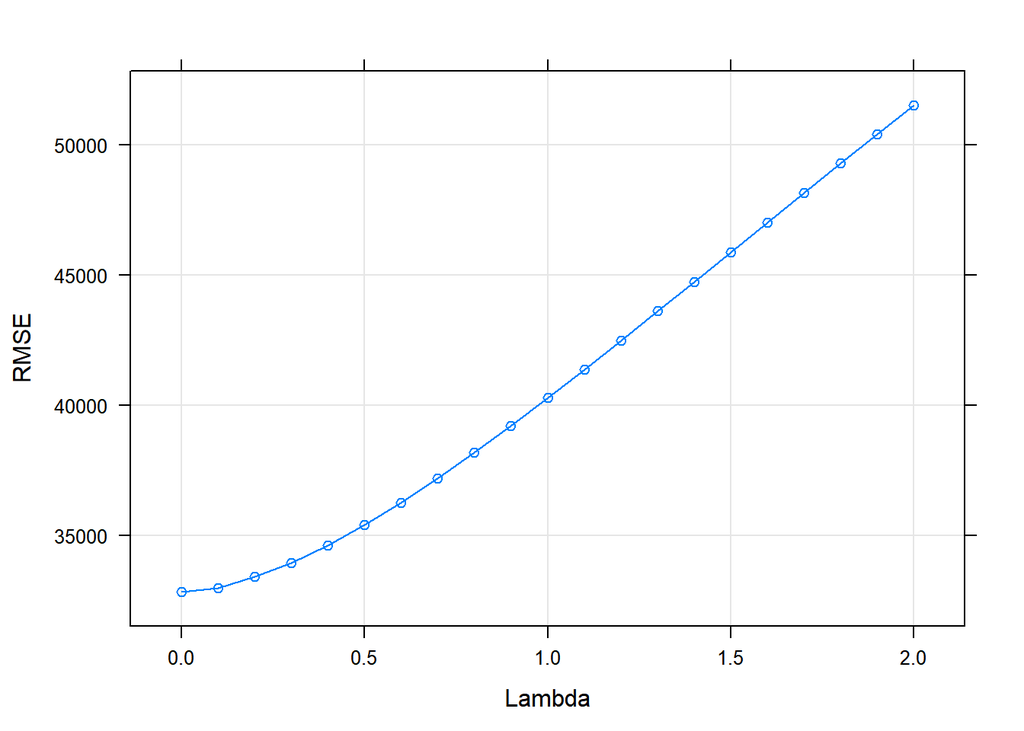

```r
plot(ridge,xlab="Lambda",ylab = "RMSE")
```

Também podemos observar nos gráficos que eles se equiparam quase no mesmo ponto(na variável RMSE)

# 3.Quais as variáveis mais importantes segundo o modelo de regressão Ridge e Lasso? Variáveis foram descartadas pelo Lasso? Quais?

```r
varImp(lasso)
```

```
## loess r-squared variable importance
##
##   only 20 most important variables shown (out of 21)
##
##                                        Overall
## total_receita                         100.0000
## total_despesa                          97.9650
## quantidade_despesas                    63.6618
## recursos_de_pessoas_juridicas          55.4757
## recursos_de_partidos                   52.1134
## quantidade_doacoes                     49.1278
## quantidade_fornecedores                44.3243
## media_receita                          40.2837
## quantidade_doadores                    37.8452
## recursos_pessoas_fisicas               28.2281
## media_despesa                          23.3008
## recursos_proprios                       9.7776
## sexo                                    5.0992
## grau                                    4.0425
## numero_cadidato                         3.8759
## estado_civil                            2.9368
## idade                                   1.8629
## recursos_de_outros_candidatos.comites   1.6231
## sequencial_candidato                    0.3681
## partido                                 0.2424
```

```r
varImp(ridge)
```

```
## loess r-squared variable importance
##
##   only 20 most important variables shown (out of 23)
##
##                                        Overall
## total_receita                         100.0000
## total_despesa                          97.9650
## quantidade_despesas                    63.6618
## recursos_de_pessoas_juridicas          55.4757
## recursos_de_partidos                   52.1134
## quantidade_doacoes                     49.1278
## quantidade_fornecedores                44.3243
## media_receita                          40.2837
## quantidade_doadores                    37.8452
## recursos_pessoas_fisicas               28.2281
## media_despesa                          23.3008
## recursos_proprios                       9.7776
## sexo                                    5.0992
## grau                                    4.0425
## numero_cadidato                         3.8759
## estado_civil                            2.9368
## idade                                   1.8629
## recursos_de_outros_candidatos.comites   1.6231
## setor_economico_despesa                 1.2200
## sequencial_candidato                    0.3681
```

Enquanto o lasso nos mostra 20 num total de 21, o Ridge mostra 20 de 23, ou seja, leva em consideração mais variáveis do que o lasso. Existe uma pequena diferença quando vemos as variáveis que foram escolhidas entre uma e outra, mas nenhuma das mais significativas foi alterada.

# 4.Re-treine o melhor modelo (usando os melhores valores de parâmetros encontrados em todos os dados, sem usar validação cruzada).

```r
ridge_no_cv <- train(votos ~ ., data = df %>% select(-cargo) %>% select(-nome),
               method='ridge',
               tuneGrid = lambda.grid,
               metric='RMSE',
               preProcess=c('scale', 'center','nzv'))


ridge_no_cv
```

```
## Ridge Regression
##
## 4152 samples
##   23 predictor
##
## Pre-processing: scaled (34), centered (34), remove (192)
## Resampling: Bootstrapped (25 reps)
## Summary of sample sizes: 4152, 4152, 4152, 4152, 4152, 4152, ...
## Resampling results across tuning parameters:
##
##   lambda  RMSE      Rsquared   MAE
##   0.0     34921.36  0.4307630  13188.73
##   0.1     34518.48  0.4448812  12836.44
##   0.2     34951.09  0.4477041  13121.93
##   0.3     35551.99  0.4498547  13533.91
##   0.4     36284.83  0.4515682  14045.06
##   0.5     37126.73  0.4529407  14627.65
##   0.6     38058.13  0.4540468  15268.12
##   0.7     39062.09  0.4549442  15953.25
##   0.8     40124.03  0.4556772  16671.80
##   0.9     41231.55  0.4562797  17416.43
##   1.0     42374.17  0.4567777  18174.81
##   1.1     43543.07  0.4571913  18941.84
##   1.2     44730.86  0.4575364  19709.92
##   1.3     45931.35  0.4578252  20476.47
##   1.4     47139.37  0.4580676  21242.70
##   1.5     48350.63  0.4582714  22005.35
##   1.6     49561.54  0.4584431  22762.84
##   1.7     50769.13  0.4585879  23512.21
##   1.8     51970.94  0.4587099  24253.96
##   1.9     53164.93  0.4588126  24988.02
##   2.0     54349.42  0.4588989  25712.42
##
## RMSE was used to select the optimal model using the smallest value.
## The final value used for the model was lambda = 0.1.
```

Aqui já temos um lambda maior, mas não muita coisa(o bias continua sendo baixo e a variância alta).

```r
ridge_pred_no_cv <- predict(ridge_no_cv,df %>% select(-cargo) %>% select(-nome) %>% select(-votos))

ridge.data_no_cv <- data.frame(pred = ridge_pred_no_cv, obs = df$votos)

ridge_show_no_cv <- round(defaultSummary(ridge.data_no_cv),digits = 4)

ridge_show_no_cv
```

```
##       RMSE   Rsquared        MAE
## 32880.1752     0.4745 12231.4245
```

Como corriqueiro acontecimento no nosso estudo, temos um R² maior nos testes do que no treino. Como agora não usamos validação cruzada, podemos ver como se saíram:

*CV:(R²)0.4889*

*NO_CV:(R²)0.4745*

percebemos que, sem a validação cruzada, o R² nos testes foi menor do que com a validação, não sendo a melhor opção no nosso caso.

# 5.Use esse último modelo treinado para prever os dados de teste disponíveis no challenge que criamos na plataforma Kaggle

```r
testeKaggle <- read.csv("C:/Users/João Lucas/Desktop/test.csv")



colnames(testeKaggle)[13] <- "recursos_pessoas_fisicas"

media_partidos_testeKaggle <- mean(testeKaggle$recursos_de_partidos, na.rm = TRUE)
testeKaggle$recursos_de_partidos[is.na(testeKaggle$recursos_de_partidos)] <- media_partidos_testeKaggle

media_comites_testeKaggle <- mean(testeKaggle$recursos_de_outros_candidatos.comites, na.rm = TRUE)
testeKaggle$recursos_de_outros_candidatos.comites[is.na(testeKaggle$recursos_de_outros_candidatos.comites)] <- media_comites_testeKaggle

media_proprios_testeKaggle <- mean(testeKaggle$recursos_proprios, na.rm = TRUE)
testeKaggle$recursos_proprios[is.na(testeKaggle$recursos_proprios)] <- media_proprios_testeKaggle

media_fisicas_testeKaggle <- mean(testeKaggle$recursos_pessoas_fisicas, na.rm = TRUE)
testeKaggle$recursos_pessoas_fisicas[is.na(testeKaggle$recursos_pessoas_fisicas)] <- media_fisicas_testeKaggle

media_juridicas_testeKaggle <- mean(testeKaggle$recursos_de_pessoas_juridicas, na.rm = TRUE)
testeKaggle$recursos_de_pessoas_juridicas[is.na(testeKaggle$recursos_de_pessoas_juridicas)] <- media_juridicas_testeKaggle


testeKaggle <-testeKaggle[,-c(6,20)]
```

```r
trainKaggle <- read.csv("C:/Users/João Lucas/Desktop/train.csv")


colnames(trainKaggle)[13] <- "recursos_pessoas_fisicas"

media_partidos_trainKaggle <- mean(trainKaggle$recursos_de_partidos, na.rm = TRUE)
trainKaggle$recursos_de_partidos[is.na(trainKaggle$recursos_de_partidos)] <- media_partidos_trainKaggle

media_comites_trainKaggle <- mean(trainKaggle$recursos_de_outros_candidatos.comites, na.rm = TRUE)
trainKaggle$recursos_de_outros_candidatos.comites[is.na(trainKaggle$recursos_de_outros_candidatos.comites)] <- media_comites_trainKaggle

media_proprios_trainKaggle <- mean(trainKaggle$recursos_proprios, na.rm = TRUE)
trainKaggle$recursos_proprios[is.na(trainKaggle$recursos_proprios)] <- media_proprios_trainKaggle

media_fisicas_trainKaggle <- mean(trainKaggle$recursos_pessoas_fisicas, na.rm = TRUE)
trainKaggle$recursos_pessoas_fisicas[is.na(trainKaggle$recursos_pessoas_fisicas)] <- media_fisicas_trainKaggle

media_juridicas_trainKaggle <- mean(trainKaggle$recursos_de_pessoas_juridicas, na.rm = TRUE)
trainKaggle$recursos_de_pessoas_juridicas[is.na(trainKaggle$recursos_de_pessoas_juridicas)] <- media_juridicas_trainKaggle

trainKaggle <-trainKaggle[,-c(6,21)]
```

```r
lasso_kaggle <- train(votos ~ ., trainKaggle %>% select(-nome) %>% select(-cargo) %>% select(-ID),
               method='lasso',
               metric='RMSE',
               tuneLength = 50,
               preProcess=c('scale', 'center','nzv'))


lasso_kaggle
```

```
## The lasso
##
## 4152 samples
##   20 predictor
##
## Pre-processing: scaled (31), centered (31), remove (52)
## Resampling: Bootstrapped (25 reps)
## Summary of sample sizes: 4152, 4152, 4152, 4152, 4152, 4152, ...
## Resampling results across tuning parameters:
##
##   fraction   RMSE      Rsquared   MAE
##   0.1000000  33569.85  0.4423866  16752.83
##   0.1163265  32892.51  0.4468132  16031.83
##   0.1326531  32344.56  0.4523107  15376.80
##   0.1489796  31926.68  0.4574664  14796.80
##   0.1653061  31609.89  0.4614813  14286.18
##   0.1816327  31375.58  0.4645836  13828.76
##   0.1979592  31203.59  0.4671356  13435.07
##   0.2142857  31061.76  0.4695486  13113.66
##   0.2306122  30961.69  0.4710199  12858.11
##   0.2469388  30895.78  0.4718977  12642.94
##   0.2632653  30850.88  0.4727168  12473.39
##   0.2795918  30820.95  0.4735976  12353.37
##   0.2959184  30809.30  0.4741927  12270.18
##   0.3122449  30809.70  0.4746101  12224.23
##   0.3285714  30801.10  0.4753634  12205.50
##   0.3448980  30806.55  0.4757390  12209.08
##   0.3612245  30804.31  0.4760771  12211.65
##   0.3775510  30806.94  0.4762848  12221.21
##   0.3938776  30803.79  0.4766300  12235.40
##   0.4102041  30798.73  0.4770211  12255.19
##   0.4265306  30792.11  0.4774622  12277.42
##   0.4428571  30786.95  0.4778458  12302.23
##   0.4591837  30783.99  0.4781673  12331.71
##   0.4755102  30780.90  0.4784848  12361.03
##   0.4918367  30779.37  0.4787619  12391.50
##   0.5081633  30778.10  0.4790382  12424.28
##   0.5244898  30777.74  0.4792527  12456.07
##   0.5408163  30778.22  0.4794247  12488.46
##   0.5571429  30772.66  0.4797096  12518.67
```

[output cut: 9 more lines]

```
##   0.7204082  30766.28  0.4804369  12783.81
##   0.7367347  30771.69  0.4802874  12805.59
##   0.7530612  30777.82  0.4801181  12827.68
##   0.7693878  30782.69  0.4799761  12845.95
##   0.7857143  30788.41  0.4798128  12863.83
##   0.8020408  30794.90  0.4796352  12879.99
##   0.8183673  30802.10  0.4794438  12895.47
##   0.8346939  30810.54  0.4792219  12911.30
##   0.8510204  30820.07  0.4789665  12926.81
##   0.8673469  30830.74  0.4786797  12942.34
##   0.8836735  30842.55  0.4783654  12958.03
##   0.9000000  30855.47  0.4780251  12973.93
##
## RMSE was used to select the optimal model using the smallest value.
## The final value used for the model was fraction = 0.6387755.
```

```r
lasso_kaggle_predict <- predict(lasso_kaggle,testeKaggle %>% select(-ID))

lasso_kaggle_data <- data.frame(id = testeKaggle$ID,votos = lasso_kaggle_predict)

write.csv(lasso_kaggle_data,"lasso_kaggle.csv",row.names = F)

exampleJoao_lasso <- read.csv("C:/Users/João Lucas/Documents/ad2/Lab4/lasso_kaggle.csv")

exampleVotos <-abs(exampleJoao_lasso$votos)

lasso_kaggle_example <- data.frame(id = testeKaggle$ID, votos = exampleVotos)

write.csv(lasso_kaggle_example,"lasso_kaggle_example.csv",row.names = F)
example_Joao_lasso <- read.csv("C:/Users/João Lucas/Documents/ad2/Lab4/lasso_kaggle_example.csv")
```